# Analysis 3/14

## Update on Analysis

See SQL files for detail on queries used to generate these datasets

In short, I queried the SQL database to find all transactions where Customs and Border Patrol, Immigration and Customs Enforcement, and the Executive Office of Immigration review were either funding or awarding agencies.

This code is pretty quick - maybe 20 minutes to produce all datasets, so feel free to run it yourself.

```
##
## Awarding Transactions:
```

```
## [1] 289340
```

```
##
## Funding Transactions:
```

```
## [1] 154261
```

```
##
## Total Transactions:
```

```
## [1] 300319
```

### Duplicated transaction IDs

To check that we don’t have a ton of duplicated transactions in the dataset, I checked the number of observations occuring for each transaction ID. The resulting table shows that some transaction IDs are repeated over 100 times each in the dataset, which may be problematic:

```r
alldat %>% group_by(award_id) %>% summarise(count = n()) %>% arrange(desc(count)) %>% head()
```

| award_id | count |
| --- | --- |
| 69245855 | 132 |
| 23819538 | 115 |
| 23764910 | 106 |
| 68902925 | 97 |
| 23819733 | 95 |
| 23775385 | 94 |

But on further inspectioon, these appear to renewed contracts with the same ID. Below are the first 6 rows for the most common transaction ID, which looks like a contract for guard service that is continued every year. An important note here is that the total obligation is consistent across all of these shared transactions, but the pragmatic obligation varies substantially.

```r
alldat[alldat$award_id == 69245855,]  %>% head()
```

| award_id | action_date | fiscal_year | total_obligation | generated_pragmatic_obligation | transaction_description | award_category | pop_country_name | pop_state_code | pop_county_name | pop_zip5 | naics_code | awarding_subtier_agency_name | funding_subtier_agency_name | business_categories |
| --- | --- | --- | --- | --- | --- | --- | --- | --- | --- | --- | --- | --- | --- | --- |
| 69245855 | 14515 | 2009 | 73439858 | 0.00 | GUARD |  |  |  |  | NA | 561612 | U.S. Immigration and Customs Enforcement |  | {small_business,native_american_owned_business,8a_program_participant,special_designations,emerging_small_business,minority_owned_business,category_business,self_certified_small_disadvanted_business,s… |
| 69245855 | 14508 | 2009 | 73439858 | -36512.05 | GUARD |  |  |  |  | NA | 561612 | U.S. Immigration and Customs Enforcement |  | {small_business,native_american_owned_business,8a_program_participant,special_designations,emerging_small_business,minority_owned_business,category_business,self_certified_small_disadvanted_business,s… |
| 69245855 | 14505 | 2009 | 73439858 | 0.00 | GUARD |  |  |  |  | NA | 561612 | U.S. Immigration and Customs Enforcement |  | {small_business,native_american_owned_business,8a_program_participant,special_designations,emerging_small_business,minority_owned_business,category_business,self_certified_small_disadvanted_business,s… |
| 69245855 | 14504 | 2009 | 73439858 | -23132.25 | GUARD |  |  |  |  | NA | 561612 | U.S. Immigration and Customs Enforcement |  | {small_business,native_american_owned_business,8a_program_participant,special_designations,emerging_small_business,minority_owned_business,category_business,self_certified_small_disadvanted_business,s… |
| 69245855 | 14504 | 2009 | 73439858 | 24286.06 | GUARD |  |  |  |  | NA | 561612 | U.S. Immigration and Customs Enforcement |  | {small_business,native_american_owned_business,8a_program_participant,special_designations,emerging_small_business,minority_owned_business,category_business,self_certified_small_disadvanted_business,s… |
| 69245855 | 14504 | 2009 | 73439858 | -28048.80 | GUARD |  |  |  |  | NA | 561612 | U.S. Immigration and Customs Enforcement |  | {small_business,native_american_owned_business,8a_program_participant,special_designations,emerging_small_business,minority_owned_business,category_business,self_certified_small_disadvanted_business,s… |

To me, this seems like evidence we should be working with the pragmatic obligation, not just the total obligation.

### Distribution of pragmatic obligation

As additional error checking, I’ve also plotted the distribution of generated obligations, both raw and the log10 + 1 transformation of absolute values. Most transactions seem to have zero cost or are relatively small – in the range of 100 - 10,000 dollars – but there are a few extremes. I’ve highlighted one example below:

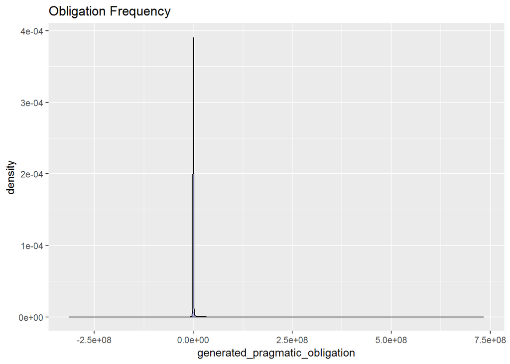

```r
alldat %>%
  ggplot(aes(x = generated_pragmatic_obligation)) +
  geom_density(fill = "blue", alpha = .25) +
  ggtitle("Obligation Frequency")
```

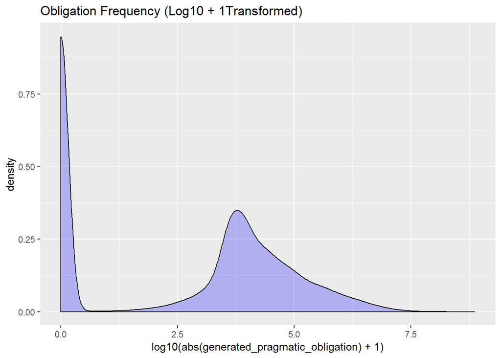

```r
alldat %>%
  ggplot(aes(x = log10(abs(generated_pragmatic_obligation) + 1))) +
  geom_density(fill = "blue", alpha = .25) +
  ggtitle("Obligation Frequency (Log10 + 1Transformed)")
```

This looks like some massive overspending for some sort of fencing project. As an aside, I think it’d be neat to see if we can figure out which transactions are most likely to go over budget.

```r
alldat[alldat$generated_pragmatic_obligation == max(alldat$generated_pragmatic_obligation),]
```

| award_id | action_date | fiscal_year | total_obligation | generated_pragmatic_obligation | transaction_description | award_category | pop_country_name | pop_state_code | pop_county_name | pop_zip5 | naics_code | awarding_subtier_agency_name | funding_subtier_agency_name | business_categories |
| --- | --- | --- | --- | --- | --- | --- | --- | --- | --- | --- | --- | --- | --- | --- |
| 23796632 | 13885 | 2008 | 311334064 | 733273500 | SUPPLY AND SUPPLY CHAIN MANAGEMENT IN SUPPORT OF PEDESTRIAN FENCE 225 AND VEHICLE FENCE 300 PROJECTS | contract | UNITED STATES | VA | ARLINGTON | 22202 | 541990 | U.S. Customs and Border Protection |  | {other_than_small_business,category_business} |

### Does total yearly obligation match government figures?

Below is a table of official statistics reported by the current presidential administration on border funding:

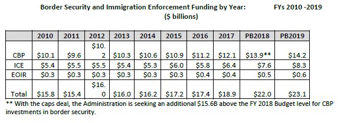

When we compare these with spending totals generated from our data, it seems that the USASpending dataset is likely under-reporting by 50% or more. Aside from an error in my code, this could be the result of limited reporting requirements of the Department of Homeland Security to this dataset.

| fiscal_year | total_obligation | total_obligation_Bn | total_prag_obligation | total_prag_obligation_Bn | nonneg_prag_obligation | nonneg_prag_obligation_Bn |
| --- | --- | --- | --- | --- | --- | --- |
| 2002 | 0 | 0.000000 | 0 | 0.0000000 | NA | NA |
| 2003 | 2041750154 | 2.041750 | 653741269 | 0.6537413 | 670709717 | 0.6707097 |
| 2004 | 21840631480 | 21.840631 | 2181119039 | 2.1811190 | 2223242115 | 2.2232421 |
| 2005 | 38539013307 | 38.539013 | 2378107112 | 2.3781071 | 2419387781 | 2.4193878 |
| 2006 | 53829902573 | 53.829903 | 3450620830 | 3.4506208 | 3516908393 | 3.5169084 |
| 2007 | 64155949129 | 64.155949 | 4312791703 | 4.3127917 | 4428567407 | 4.4285674 |
| 2008 | 92594002814 | 92.594003 | 5956831222 | 5.9568312 | 6997584407 | 6.9975844 |
| 2009 | 101987011243 | 101.987011 | 5082101472 | 5.0821015 | 5370392325 | 5.3703923 |
| 2010 | 68220555240 | 68.220555 | 4437099783 | 4.4370998 | 4770678983 | 4.7706790 |
| 2011 | 83395595037 | 83.395595 | 3373196199 | 3.3731962 | 3683223424 | 3.6832234 |

[output cut: 8 more lines]

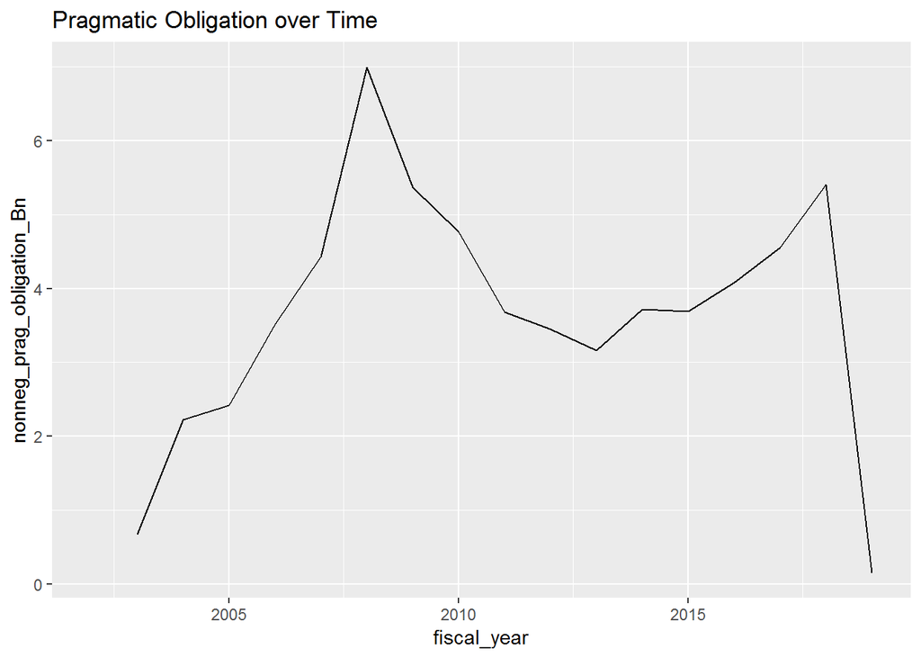